# crplot

Christopher Weld ceweld241@gmail.com, Lawrence Leemis leemis@math.wm.edu

2026-03-02

## Introduction

The `crplot` function is part of the conf package. It generates a two-dimensional confidence region plot for the specified two-parameter parametric distribution, fitted to a dataset. Details of the plot algorithm employed by `crplot` are available in its corresponding publication[^1].

A second `crplot` vignette titled *crplot Advanced Options* is available via a link found on the conf package webpage. It focuses on `crplot` optional arguments that are helpful to troubleshoot plot issues. The default `crplot` algorithm, however, is robust over a wide range of plot circumstances with varying levels of difficulty and its users should therefore familiarize with this vignette first.

## Installation Instructions

The `crplot` function is accessible following installation of the `conf` package:

```
install.packages("conf")
library(conf)
```

## Example

The dataset for ball bearing failure times, given by Lieblein and Zelen[^2], is used throughout this example. Its fit to the Weibull distribution, including the confidence region illustrated next, is also explained in depth in the Reliability textbook by Leemis[^3].

After reading ball bearing failure times (in millions of revolutions) into the vector `ballbearing`, `crplot` is called using arguments for the Weibull distribution, and a level of significance $\alpha = 0.05$ to yield a $95\%$ confidence region.

```
#> [1] "95% confidence region plot complete; made using 102 boundary points."
```

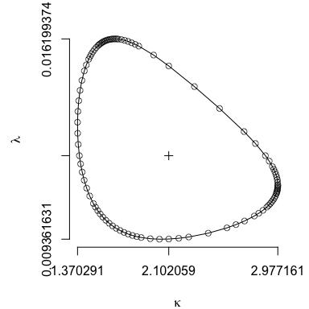

```r
library(conf)
ballbearing <- c(17.88, 28.92, 33.00, 41.52, 42.12, 45.60, 48.48, 51.84,
                 51.96, 54.12, 55.56, 67.80, 68.64, 68.64, 68.88, 84.12,
                 93.12, 98.64, 105.12, 105.84, 127.92, 128.04, 173.40)
crplot(dataset = ballbearing, alpha = 0.05, distn = "weibull")
```

The maximum likelihood estimator is plot as a + within the confidence region. In addition to the $95\%$ confidence region plot, output informs the user that its smoothing boundary search heuristic (default heuristic) uses 102 points to complete the plot. The smoothing boundary search heuristic confidence region build process is illustrated using the optional argument `animate = TRUE`.

```
#> [1] "95% confidence region plot complete; made using 102 boundary points."
```

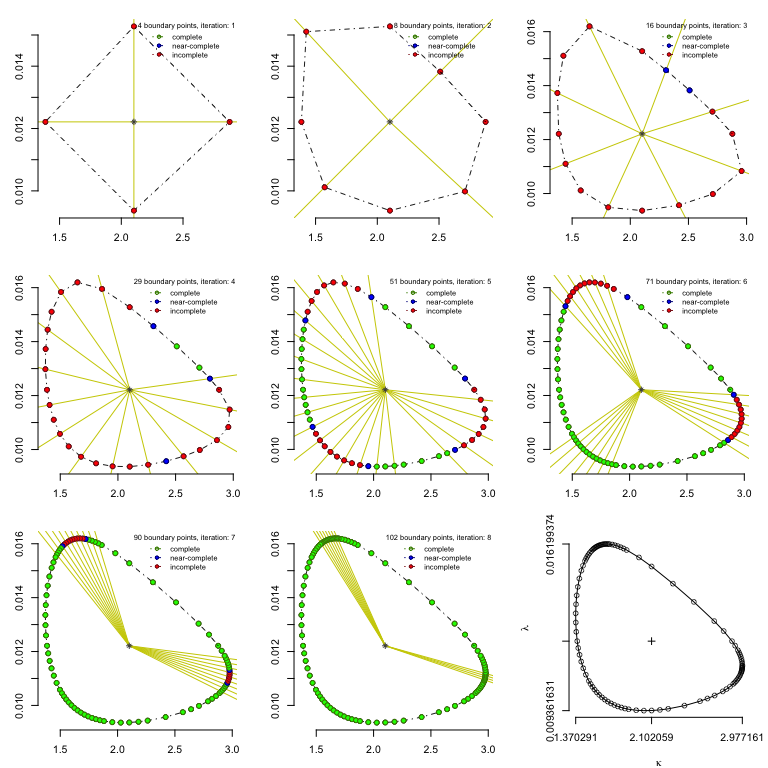

```r
par(mfrow = c(3, 3))
crplot(dataset = ballbearing, alpha = 0.05, distn = "weibull", animate = TRUE)
```

Valuable perspective is often given if the origin is included within a plot. The argument `origin = TRUE` in the plot below invokes this change. Alternatively, the user can specify a unique frame of reference using optional `xlim` and/or `ylim` arguments. Three additional modifications complete the plot below: its points are hidden using `pts = FALSE`, significant figures for the respective horizontal and vertical axes are specified using `sf = c(2, 4)`, and the orientation of the y-axis labels are set horizontal using `ylas = 1`.

```
#> [1] "95% confidence region plot complete; made using 102 boundary points."
```

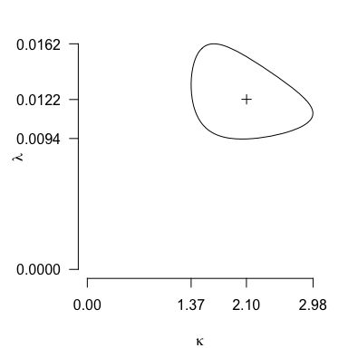

```r
crplot(dataset = ballbearing, alpha = 0.05, distn = "weibull",
       pts = FALSE, sf = c(2, 4), ylas = 1, origin = TRUE)
```

Setting `info = TRUE` allows the user to access data pertinent to the resulting plot for subsequent analysis and/or plot customization. This is shown next; also note the assignment `x <- crplot(...)`, which is necessary to collect plot data for future use.

```r
x <- crplot(dataset = ballbearing, alpha = 0.05, distn = "weibull", info = TRUE)
```

```
#> [1] "95% confidence region plot complete; made using 102 boundary points."
```

```r
str(x)
```

```
#> List of 5
#>  $ kappa    : num [1:102] 2.8 2.71 2.51 2.31 2.1 ...
#>  $ lambda   : num [1:102] 0.0126 0.013 0.0138 0.0146 0.0153 ...
#>  $ phi      : num [1:102] 0.000596 0.001361 0.00395 0.01146 1.570796 ...
#>  $ kappahat : num 2.1
#>  $ lambdahat: num 0.0122
```

Displaying `str(x)` confirms that `info = TRUE` directs `crplot` to return a list with respective arguments `"kappa"`, `"lambda"`, and `"phi"`. The `"kappa"` and `"lambda"` parameters correspond to the plot horizontal and vertical axes values. They are the Weibull distribution shape and scale parameters, respectively. These parameters update appropriately when fitting the data to the inverse Gaussian distribution (returning mean and shape parameters, `"mu"` and `"lambda"`, respectively). The third list argument, `"phi"`, gives angles in radians relative to the MLE, corresponding to each plot point. These `"phi"` ($\phi$) values determined plot points using Jaeger’s radial profile log likelihood technique[^4].

Custom plots and analysis are possible using the data returned when `info = TRUE`. Two examples follow. The first shades the confidence region and alters its border line type.

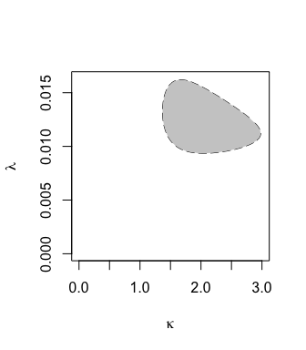

```r
# with confidence region data stored in x, it is now available for custom graphics
plot(x$kappa, x$lambda, type = 'l', lty = 5, xlim = c(0, 3), ylim = c(0, 0.0163),
     xlab = expression(kappa), ylab = expression(lambda))
polygon(x$kappa, x$lambda, col = "gray80", border = NA)
```

The second example will analyze $\phi$ angles (with respect to the MLE) used to create the confidence region plot. This is done with two plots.

The first of the two plots illustrates the confidence region plot, with segments radiating from its MLE at applicable $\phi$ values. Note the greater density of $\phi$ angles for plot regions with greater curvature. This is a consequence of the smoothing search heuristic (`heuristic = 1`) plotting algorithm used as the default plotting method for `crplot`.

The second plot is a perspective of `phi` values numerically using a cumulative distribution function. Note how most $\phi$ angles are near horizontal orientation ($0$ and $\pi$ radians, respectfully). This is a consequence of the vastly different scales for its respective parameters, $\kappa$ and $\lambda$. The *actual* $\phi$ angles required to assemble the confidence region plot can vary greatly from their *apparent* angles due to scale differences between axes.

```r
# record MLE values (previously output to screen when info = TRUE) & reproduce CR plot
kappa.hat <- 2.10206
lambda.hat <- 0.01221
crplot(dataset = ballbearing, alpha = 0.05, distn = "weibull", xlab = "shape",
       ylab = " ", main = paste0("Confidence Region"),
       pts = FALSE, mlelab = FALSE, sf = c(2, 4), origin = TRUE)
```

```
#> [1] "95% confidence region plot complete; made using 102 boundary points."
```

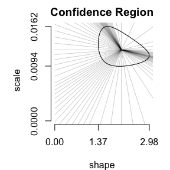

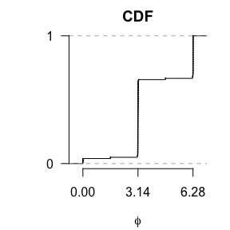

```r
par(xpd = TRUE)
text(-1.2, 0.007, "scale", srt = 90)

# 1st analysis plot: overlay phi angles (as line segments) on the confidence region plot
par(xpd = FALSE)
segments(rep(kappa.hat, length(x$phi)), rep(lambda.hat, length(x$phi)),
         x1 = kappa.hat * cos(x$phi) + kappa.hat, y1 = kappa.hat * sin(x$phi) + lambda.hat, lwd = 0.2)

# 2nd analysis plot: CDF of phi angles reveals most are very near 0 (2pi) and pi
plot.ecdf(x$phi, pch = 20, cex = 0.1, axes = FALSE, xlab = expression(phi), ylab = "", main = "CDF")
axis(side = 1, at = round(c(0, pi, 2*pi), 2))
axis(side = 2, at = c(0, 1), las = 2)
```

All confidence region plots to this point are made using the default smoothing search heuristic (`heuristic = 1`). It plots more points in border regions with higher curvature, and does so until a maximum apparent angle constraint between three successive points is met (*apparent* angles assume a square plot area and account for axes scale differences). That constraint (default $5^\circ$) is customizable using the optional `maxdeg` argument to yield plots using more points for greater definition (`maxdeg` values < 5) or with less points at a reduced resolution (`maxdeg` values > 5). Lower resolution graphics sacrifice detail and are less computationally expensive. This is significant if generating a large sample of confidence regions (i.e. hundreds of confidence regions supporting bootstrap analysis repetitions, or a large pairwise matrix evaluation).

The default `maxdeg = 5` is appropriate for most circumstances. Values of `maxdeg` < $3^\circ$ are not permitted to avoid numeric approximation complications implicit with populating too many confidence region boundary points. The plots below illustrate confidence region plot results with increased and decreased resolution.

```r
crplot(dataset = ballbearing, alpha = 0.05, distn = "weibull", ylas = 1,
       maxdeg = 3, main = "maxdeg = 3", sf = c(5, 5))
```

```
#> [1] "95% confidence region plot complete; made using 164 boundary points."
```

```r
crplot(dataset = ballbearing, alpha = 0.05, distn = "weibull", ylas = 1,
       maxdeg = 3, main = "maxdeg = 3 (pts hidden)", sf = c(5, 5), pts = FALSE)
```

```
#> [1] "95% confidence region plot complete; made using 164 boundary points."
```

```r
crplot(dataset = ballbearing, alpha = 0.05, distn = "weibull", ylas = 1,
       maxdeg = 20, main = "maxdeg = 20", sf = c(5, 5))
```

```
#> [1] "95% confidence region plot complete; made using 32 boundary points."
```

```
#> [1] "95% confidence region plot complete; made using 32 boundary points."
```

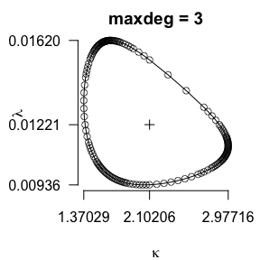

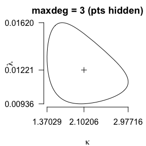

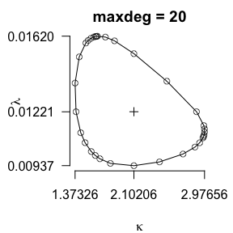

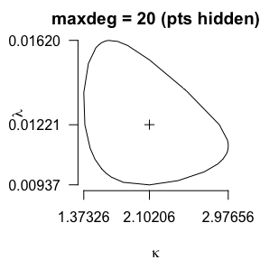

```r
crplot(dataset = ballbearing, alpha = 0.05, distn = "weibull", ylas = 1,
       maxdeg = 20, main = "maxdeg = 20 (pts hidden)", sf = c(5, 5), pts = FALSE)
```

An alternative plot heuristic is available using the optional argument `heuristic = 0`. It plots a predetermined number of confidence region points (user specified using `ellipse_n`) in a roughly uniform fashion along its boundary using an elliptic-oriented plotting technique. Its name references the method its algorithm uses to draw an ellipse—known as the parallelogram method; a result of the Theorem of Steiner[^5]—that identifies approximately equidistant points along the confidence region boundary regardless of the relative scales of its axes.

The next pair of plots illustrates differences between the default smoothing search plot heuristic and the elliptic-oriented alternative heuristic (`heuristic = 0`). They also illustrate a fit to the inverse Gaussian distribution, rather than the Weibull distribution shown previously.

```r
crplot(dataset = ballbearing, alpha = 0.05, distn = "invgauss", sf = c(2, 2),
       ylas = 1, main = "default; heuristic = 1")
```

```
#> [1] "95% confidence region plot complete; made using 103 boundary points."
```

```
#> [1] "95% confidence region plot complete; made using 100 boundary points."
```

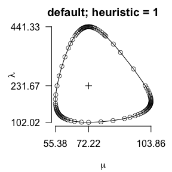

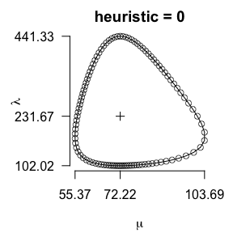

```r
crplot(dataset = ballbearing, alpha = 0.05, distn = "invgauss", sf = c(2, 2),
       ylas = 1, heuristic = 0, ellipse_n = 100, main = "heuristic = 0")
```

An `ellipse_n` value must always accompany use of `heuristic = 0`. Additionally, `ellipse_n` must be a positive integer multiple of four $\geq 8$. This requirement enables its algorithm to exploit computational efficiencies associated with ellipse symmetry throughout its respective quadrants.

Plot heuristics are combined if an `ellipse_n` value $\geq 8$ is given under default plot conditions, or equivalently `heuristic = 1`. In this case, `crplot` implements the heuristics in sequence. It begins plotting the confidence region using `ellipse_n` points through the `heuristic = 0` plot algorithm, and then augments points as necessary to meet `maxdeg` constraints corresponding to its default smoothing search heuristic.

```r
crplot(dataset = ballbearing, alpha = 0.05, distn = "invgauss", sf = c(2, 2),
       heuristic = 0, ellipse_n = 40, main = "combination: step 1")
```

```
#> [1] "95% confidence region plot complete; made using 40 boundary points."
```

```
#> [1] "95% confidence region plot complete; made using 66 boundary points."
```

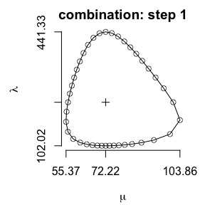

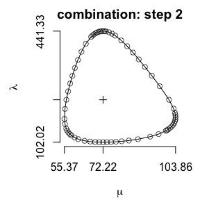

```r
crplot(dataset = ballbearing, alpha = 0.05, distn = "invgauss", sf = c(2, 2),
       maxdeg = 10, ellipse_n = 40, main = "combination: step 2")
```

The next plot illustrates the default smoothing search heuristic with `maxdeg = 10` (matching the above parameterization) for means of comparison with the combined approach above.

```
#> [1] "95% confidence region plot complete; made using 52 boundary points."
```

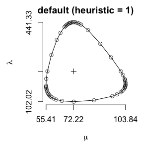

```r
crplot(dataset = ballbearing, alpha = 0.05, distn = "invgauss", sf = c(2, 2),
       maxdeg = 10, main = "default (heuristic = 1)")
```

## Right-Censored Data

Use the `crplot` optional argument `cen` to identify right-censored data values. The `cen` argument is a binary vector whose length matches `length(dataset)`. It specifies if the corresponding values in `dataset` are right-censored (0), or observed (1).

Consider the 6-MP dataset[^6] of cancer remission lengths. Its values represent the length of time (in weeks) until a cancer returns. Some patients remain cancer-free at the conclusion of the study; they comprise the dataset’s right-censored values. Among its 21 patients who were administered the 6-MP medication, nine experienced a remission (the observed values) and the remaining 12 remained cancer-free at the conclusion of the study (its right-censored data values). Its values, and the corresponding Weibull $95\%$ confidence region plot completed using `crplot`, are given below. This confidence region matches the one given on page 42 of Cox and Oaks (1984)[^7].

```
#> [1] "95% confidence region plot complete; made using 106 boundary points."
```

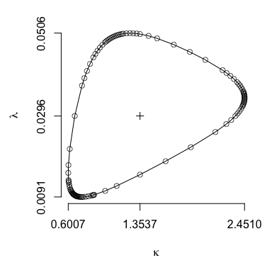

```r
mp6_obs <- c(6, 6, 6, 7, 10, 13, 16, 22, 23)                # time of cancer remission
mp6_cen <- c(6, 9, 10, 11, 17, 19, 20, 25, 32, 32, 34, 35)  # right-censored time
mp6 <- c(mp6_obs, mp6_cen)
cen <- c(rep(1, length(mp6_obs)), rep(0, length(mp6_cen)))
crplot(dataset = mp6, alpha = 0.05, distn = "weibull", cen = cen, sf = c(4, 4))
```

## Repairing Radially Inaccessible Regions

The default plot technique, known as the smoothing search heuristic and given by `heuristic = 1`, can fail to achieve its maximum apparent angle constraint (`maxdeg`, whose default is $5^\circ$). This issue arises when plotting non-convex confidence regions whose shape results in multiple confidence region boundary points at select angles from its MLE. This is often a consequence of small sample size and/or small significance level `alpha`. The optional argument `repair` corrects such circumstance. Its default is `repair = TRUE`, however, it is set to `repair = FALSE` below to illustrate these issues.

```r
X <- seq(1, 2.5, by = 0.25)
crplot(dataset = X, alpha = 0.01, distn = "gamma", sf = c(2, 2), pts = FALSE, repair = FALSE, main = "without repair")
```

```
#> [1] "99% confidence region plot complete; made using 108 boundary points."
```

```r
x <- crplot(seq(1, 2.5, by = 0.25), 0.01, "gamma", sf = c(2, 2), info = TRUE, repair = FALSE, main = "without repair")
```

```
#> [1] "99% confidence region plot complete; made using 108 boundary points."
```

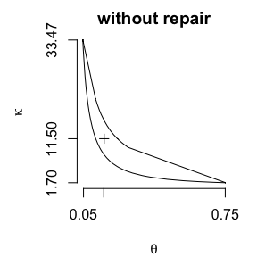

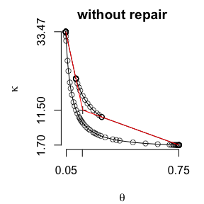

```r
index1 <- which(x$kappa == max(x$kappa))
index2 <- which(x$theta == max(x$theta))
lines(c(x$thetahat, x$theta[index1]), c(x$kappahat, x$kappa[index1]), col = "red")
lines(c(x$thetahat, x$theta[index2]), c(x$kappahat, x$kappa[index2]), col = "red")
```

Alternate-centerpoint(s) are known as “jump-center(s)”. Information regarding the jump-center(s) is returned to the user using the optional argument `jumpinfo = TRUE`. For more details regarding the jump-center algorithm and its parameters, please see the “Plotting Likelihood-Ratio Based Confidence Regions for Two-Parameter Univariate Probability Models” publication<sup>1</sup> and the `crplot_advanced` vignette via its link at the conf webpage.

Revisiting our previous example, the complete confidence region is successfully plotted below given the default argument `repair = TRUE` is unaltered. The red lines in the example above are also included below for reference. Additionally, jump-center reference points are annotated using the optional argument `showjump = TRUE`.

```r
crplot(seq(1, 2.5, by = 0.25), 0.01, "gamma", sf = c(2, 2), pts = FALSE, main = "with repair")
```

```
#> [1] "99% confidence region plot complete; made using 268 boundary points."
```

```r
crplot(seq(1, 2.5, by = 0.25), 0.01, "gamma", sf = c(2, 2), main = "with repair", showjump = TRUE)
```

```
#> [1] "99% confidence region plot complete; made using 268 boundary points."
```

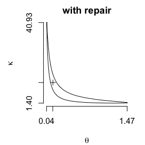

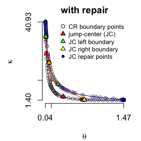

```r
lines(c(x$thetahat, x$theta[index1]), c(x$kappahat, x$kappa[index1]), col = "red")
lines(c(x$thetahat, x$theta[index2]), c(x$kappahat, x$kappa[index2]), col = "red")
```

The absence of the Warning message seen when `maxdeg` constraints are not met is indicative that they are met; the maximum apparent angle between any two successive plot points is within the `maxdeg` apparent angle tolerance of $5 ^\circ$. This is true even at the bottom-right and top-left confidence region extremes where it appears a sharp point is possible. This fact is confirmed by zooming-in on those respective areas below:

```r
crplot(seq(1, 2.5, by = 0.25), 0.01, "gamma", sf = c(2, 2), pts = TRUE, main = "max(theta) zoom", xlim = c(1.25, 1.5), ylim = c(1.4, 2.4))
```

```
#> [1] "99% confidence region plot complete; made using 268 boundary points."
```

```
#> [1] "99% confidence region plot complete; made using 268 boundary points."
```

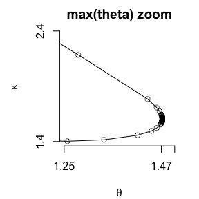

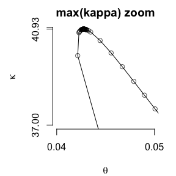

```r
crplot(seq(1, 2.5, by = 0.25), 0.01, "gamma", sf = c(2, 2), pts = TRUE, main = "max(kappa) zoom", xlim = c(0.04, 0.05), ylim = c(37, 41))
```

The final examples below demonstrate how repairs are necessary for some (log logistic and Weibull distributions) but not all (normal) distributions given this particular small sample of $n = 2$ values.

```r
  x <- crplot(c(2, 2.5), 0.01, "llogis", sf = c(2, 2), info = TRUE, pts = FALSE, main = "llogis")
```

```
#> [1] "99% confidence region plot complete; made using 238 boundary points."
```

```r
  x <- crplot(c(2, 2.5), 0.01, "weibull", sf = c(2, 2), info = TRUE, pts = FALSE, main = "weibull")
```

```
#> [1] "99% confidence region plot complete; made using 255 boundary points."
```

```
#> [1] "99% confidence region plot complete; made using 100 boundary points."
```

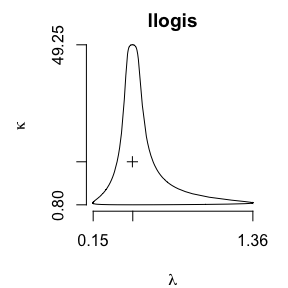

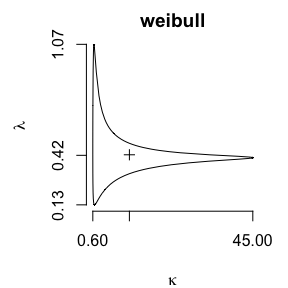

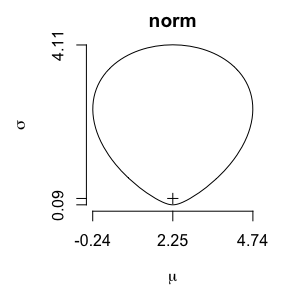

```r
  x <- crplot(c(2, 2.5), 0.01, "norm", sf = c(2, 2), info = TRUE, pts = FALSE, main = "norm")
```

Overriding the default with `repair = FALSE` is not typically recommended, but possible for two reasons. First, repairs require additional computation time that circumstance may warrant avoiding for a quicker (albeit less-precise) solution. Second, occasionally `crplot` fails to complete a confidence region plot due an R uniroot or other numeric failure. In such cases, turning off repairs can enable an otherwise unobtainable plot to return to the user.

[^1]: Weld, C., Loh, A., and Leemis, L. (in press), “Plotting Likelihood-Ratio Based Confidence Regions for Two-Parameter Univariate Probability Models”, *The American Statistician*
[^2]: Lieblein, J., and Zelen, M. (1956), Statistical Investigation of the Fatigue Life of Deep-Groove Ball Bearings, *Journal of Research of the National Bureau of Standards*, 57, 273–316
[^3]: Leemis, L. (1995), *Reliability: Probabilistic Models and Statistical Methods Second Edition*, Prentice-Hall Inc., 345–251
[^4]: Jaeger, A. (2016), “Computation of Two- and Three-Dimensional Confidence Regions With the Likelihood Ratio”, *The American Statistician*, 70, 395–398
[^5]: Meserve, B. E. (2014), *Fundamental Concepts of Geometry*, Courier Corporation
[^6]: Gehan, Edmund A. (1965), A Generalized Wilcoxon Test for Comparing Arbitrarily Singly-Censored Samples, Biometrika, 52, 650–653
[^7]: Cox, D.R. and Oakes, D. (1984), Analysis of Survival Data, New York, NY: Chapman and Hall